# R Notebook

R for Data Science

```r
install.packages("tidyverse")
```

```
Error in install.packages : Updating loaded packages
```

```r
library(tidyverse)
```

There is a data frame found in ggplot2 (aka ggplot2::mpg). A data frame is a rectangular collection of variables (in the columns) and observations (in the rows). mpg contains observations collected by the US Environment Protection Agencyon 38 models of cars.

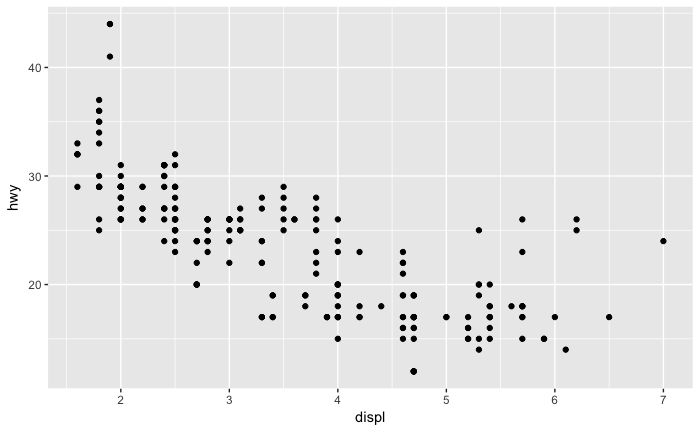

```r
ggplot(data = mpg) +  geom_point(mapping = aes(x = displ, y = hwy))
```

To make a graph, replace the bracketed sections in the fol‐ lowing code with a dataset, a geom function, or a collection of mappings:

We now get to play with different graphs we can make with the same data.

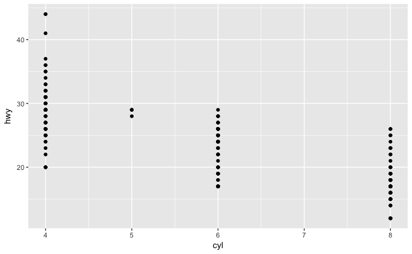

```r
#ggplot (data=mpg)
ggplot (data=mpg) + geom_point(mapping = aes(x = cyl, y = hwy))
```

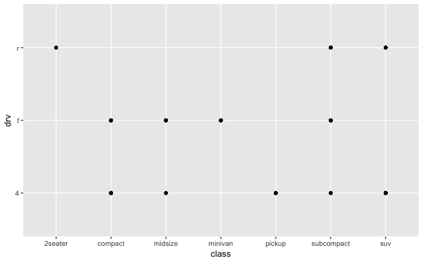

```r
ggplot (data=mpg) + geom_point(mapping = aes(x = class, y = drv)) #drv=front or rear wheel drive
```

```r
#help(mpg)
```

Back to the original plot. One group of points seems to fall outside the linear trend. Are these cars hybrids?

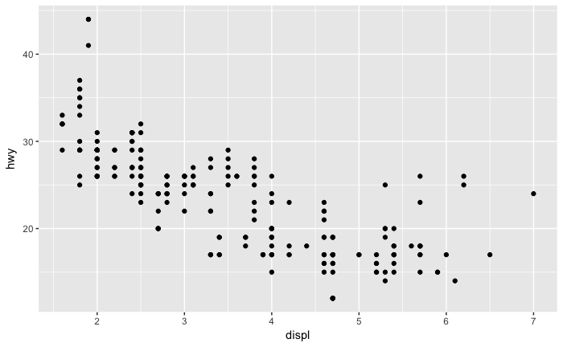

```r
ggplot(data = mpg) +  geom_point(mapping = aes(x = displ, y = hwy))
```

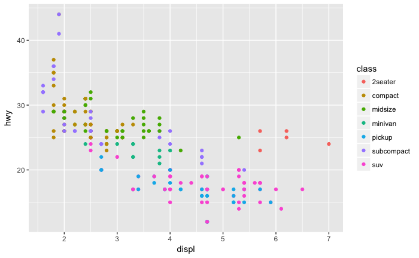

```r
ggplot(data = mpg) +  geom_point(mapping = aes(x = displ, y = hwy, colour = class))
```

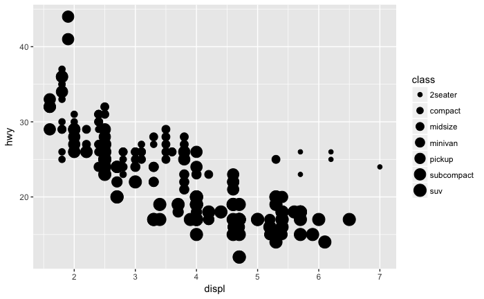

```r
ggplot(data = mpg) +  geom_point(mapping = aes(x = displ, y = hwy, size = class))#ill advised (discrete variables and size)
```

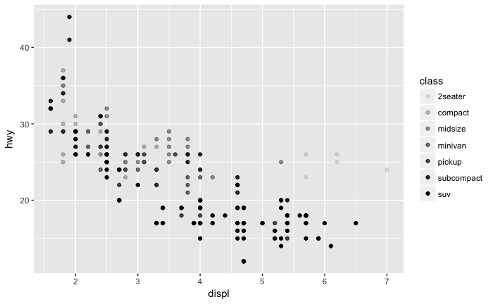

```r
ggplot(data = mpg) +  geom_point(mapping = aes(x = displ, y = hwy, alpha = class))
```

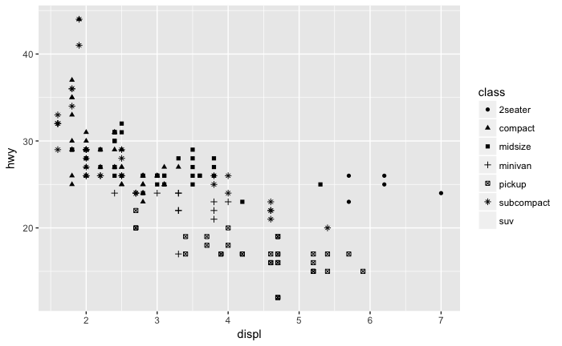

```r
ggplot(data = mpg) +  geom_point(mapping = aes(x = displ, y = hwy, shape = class))# ill advised (can only have 6 shapes)
```

```
Restarting R session...
```

# Facets

Another way,particularly useful for categorical variables, is to split your plot intofacets, subplots that each display one subset of the data.

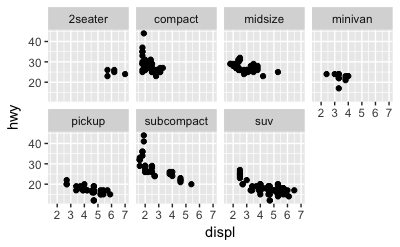

```r
ggplot(data = mpg) +  geom_point(mapping = aes(x = displ, y = hwy)) +  facet_wrap(~ class, nrow = 2)
```

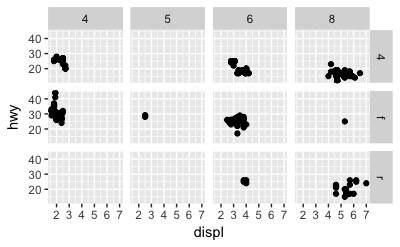

```r
ggplot(data = mpg) +  geom_point(mapping = aes(x = displ, y = hwy)) +  facet_grid(drv ~ cyl)
```

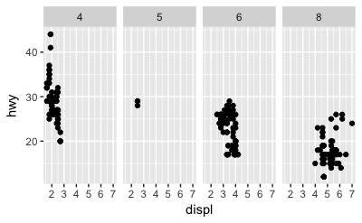

```r
ggplot(data = mpg) +  geom_point(mapping = aes(x = displ, y = hwy)) +  facet_grid(. ~ cyl)
```

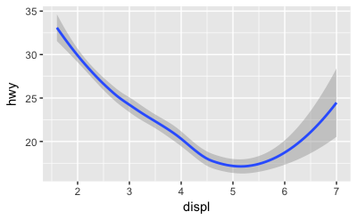

```r
ggplot(data = mpg) +  geom_smooth(mapping = aes(x = displ, y = hwy))
```

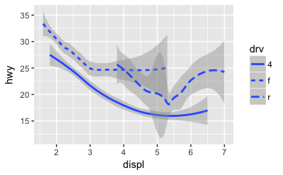

```r
ggplot(data = mpg) +  geom_smooth(mapping = aes(x = displ, y = hwy, linetype = drv))
```

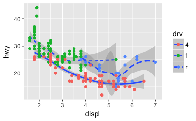

```r
ggplot(data = mpg) +  geom_smooth(mapping = aes(x = displ, y = hwy, linetype = drv)) +geom_point(mapping=aes(x =displ, y= hwy, colour = drv))
```

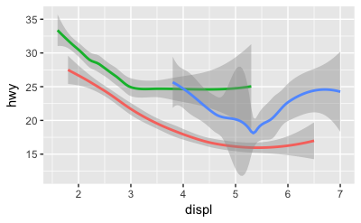

```r
ggplot(data = mpg) +  geom_smooth(    mapping = aes(x = displ, y = hwy, color = drv),    show.legend = FALSE  )
```

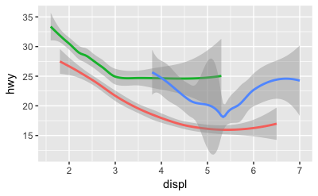

```r
ggplot(data = mpg) +  geom_smooth(    mapping = aes(x = displ, y = hwy, color = drv),    show.legend = FALSE  )
```

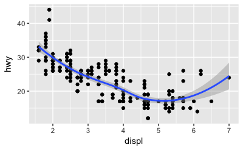

```r
ggplot(data = mpg, mapping = aes(x = displ, y = hwy)) +  geom_point() +  geom_smooth()
```

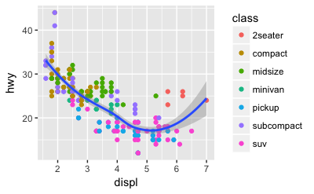

```r
ggplot(data = mpg, mapping = aes(x = displ, y = hwy)) +  geom_point(mapping = aes(color = class)) +  geom_smooth()
```

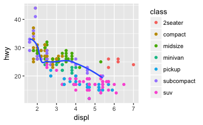

```r
ggplot(data = mpg, mapping = aes(x = displ, y = hwy)) +  geom_point(mapping = aes(color = class)) +  geom_smooth(    data = filter(mpg, class == "subcompact"),    se = FALSE  )
```

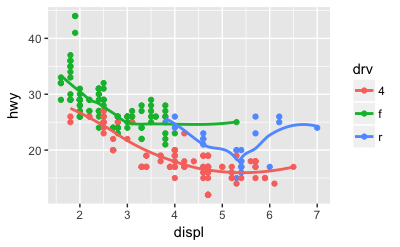

```r
ggplot(  data = mpg,  mapping = aes(x = displ, y = hwy, color = drv)) +  geom_point() +  geom_smooth(se = FALSE)
```

# Statistical Transformations

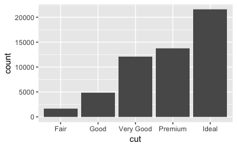

```r
ggplot (data=diamonds) + geom_bar(mapping=aes(x=cut))
```

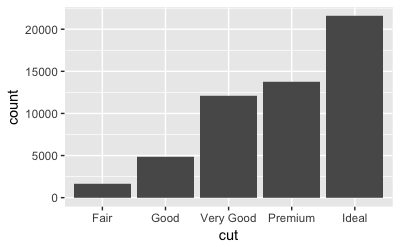

```r
ggplot(data = diamonds) +  stat_count(mapping = aes(x = cut))
```

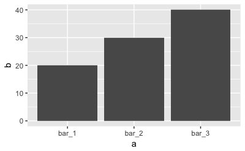

```r
demo <- tribble(  ~a,      ~b,   "bar_1", 20,  "bar_2", 30,    "bar_3", 40)
ggplot(data = demo) +  geom_bar(    mapping = aes(x = a, y = b), stat = "identity"  )
```

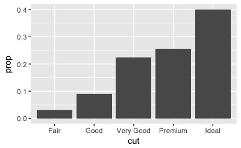

```r
ggplot(data = diamonds) +  geom_bar(    mapping = aes(x = cut, y = ..prop.., group = 1)  )
```

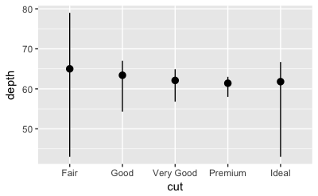

```r
ggplot(data = diamonds) +  stat_summary(    mapping = aes(x = cut, y = depth),    fun.ymin = min,    fun.ymax = max,    fun.y = median  )
```

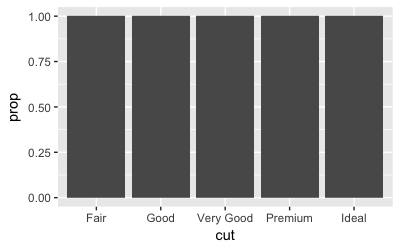

```r
ggplot(data = diamonds) +  geom_bar(mapping = aes(x = cut, y = ..prop..))
```

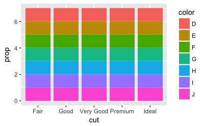

```r
ggplot(data = diamonds) +  geom_bar(    mapping = aes(x = cut, fill = color, y = ..prop..)  )
```

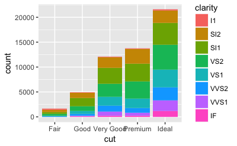

```r
ggplot(data = diamonds) +  geom_bar(mapping = aes(x = cut, fill = clarity))
```

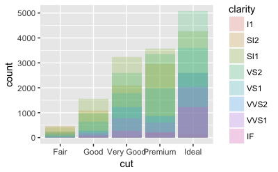

```r
ggplot(  data = diamonds,  mapping = aes(x = cut, fill = clarity)) +  geom_bar(alpha = 1/5, position = "identity")
```

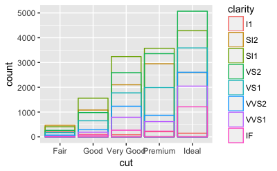

```r
ggplot(  data = diamonds,  mapping = aes(x = cut, color = clarity)) +  geom_bar(fill = NA, position = "identity")
```